# Assignment 2: Bureau of Transportation Statistics (BTS) Finance

Christina Moss and Hao Zhu

2025-02-26

## Exploring Financial Trends Across Airports with Shared Traits

In this analysis we will examine financial and budgeting patterns at the Savannah/Hilton Head International Airport and the Charleston International Airport. The cities of Savannah, GA and Charleston, SC are both attractive tourist destinations in the coastal south with relatively similar population sizes. The population of Charleston sits at around 155,000 residents and the populations of Savannah is at approximately 148,000 residents. Both cities boast picturesque parks, lovely cobblestone roads, and beautiful historic homes. This analysis will explore financial trends at the airports attached to these cities over the course of three years, 2021 to 2023.

### Data Preparation

```r
dat_2021 <- read_csv("Report127_2021.csv",
                     skip = 3,
                     na = "",
                     show_col_types = FALSE)
names(dat_2021) <- trimws(names(dat_2021))

dat_2022 <- read_csv("Report127_2022.csv",
                     skip = 3,
                     na = "",
                     show_col_types = FALSE)
names(dat_2022) <- trimws(names(dat_2022))

dat_2023 <- read_csv("Report127_2023.csv",
                     skip = 3,
                     na = "",
                     show_col_types = FALSE)
names(dat_2023) <- trimws(names(dat_2023))
```

```r
charleston_sav_2123 <- rbind(
  dat_2021 %>%
    filter(`Airport Name` %in% c("CHARLESTON INTL", "SAVANNAH INTERNATIONAL")),
  dat_2022 %>%
    filter(`Airport Name` %in% c("CHARLESTON INTL", "SAVANNAH INTERNATIONAL")),
  dat_2023 %>%
    filter(`Airport Name` %in% c("CHARLESTON INTL", "SAVANNAH INTERNATIONAL")))

charleston_sav_2123 <- charleston_sav_2123 %>%
  mutate(
    Year = as.numeric(substr(FYE, nchar(FYE)-3, nchar(FYE)))  # Extract last 4 characters for year
  )

# Verify the result
#print(charleston_sav_2123 %>%
  #select(`Airport Name`, FYE, Year) %>%
  #arrange(Year, FYE))
```

```r
# Select relevant columns for analysis
charleston_sav_analysis <- charleston_sav_2123 %>%
  select(
    # Identifying Information
    `Airport Name`,
    `Hub Size`,
    State,
    Year,

    # Key Revenue Metrics
    `Passenger airline landing fees`,
    `Terminal arrival fees - rents - utilities`,
    `Total Passenger Airline Aeronautical Revenue`,
    `Total Non-Passenger Aeronautical Revenue`,
    `Total Aeronautical Revenue`,
    `Parking and ground transportation`,
    `Terminal-food and beverage`,
    `Terminal-retail stores and duty free`,
    `Rental cars-excludes customer facility charges`,
    `Total Non-Aeronautical Revenue`,
    `Total Operating Revenue`,

    # Key Cost Metrics
    `Personnel compensation and benefits`,
    `Communications and utilities`,
    `Supplies and materials`,
    `Contractual services`,
    `Total Operating Expenses`,
    `Operating Income`,

    # Operational Metrics
    Enplanements,
    `Landed weights in pounds`,
    `Annual aircraft operations`,
    `Passenger airline cost per enplanement`,
    `Full time equivalent employees at end of year`
  )

# Check the structure
#glimpse(charleston_sav_analysis)
```

## Exploring Revenue Breakdown Over Time

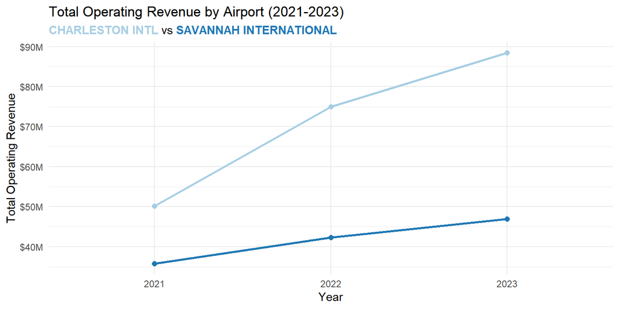

```r
# 1. total revenue comparison
ggplot(charleston_sav_analysis,
       aes(x = factor(Year), y = `Total Operating Revenue`,
           color = `Airport Name`,
           group = `Airport Name`)) +
  geom_line(size = 1) +
  geom_point(size = 2) +
  scale_color_brewer(palette = "Paired") +
  scale_x_discrete(breaks = c("2021", "2022", "2023")) +
  scale_y_continuous(labels = scales::label_number(prefix = "$", suffix = "M", scale = 1e-6)) +
  theme_minimal() +
    theme(plot.subtitle = element_markdown()) +
  labs(title = "Total Operating Revenue by Airport (2021-2023)",
             subtitle = " **<span style='color:#a6cee3;'>CHARLESTON INTL</span>** vs **<span style='color:#1f78b4;'>SAVANNAH INTERNATIONAL</span>**",

       y = "Total Operating Revenue",
       x = "Year",
       color = "Airport Name") +
  theme(
  legend.position = "none",
  plot.subtitle = element_markdown())
```

Both airports show consistent revenue growth from 2021-2023, but Charleston International significantly outperforms Savannah with nearly double the revenue. While Savannah increased from $35M to $47M (34% growth), Charleston experienced more dramatic growth from $50M to $90M (80% growth). Despite their different scales, both airports demonstrate similar patterns of continued revenue growth throughout the period, reflecting the broader recovery and expansion in the regional air travel market following the pandemic.

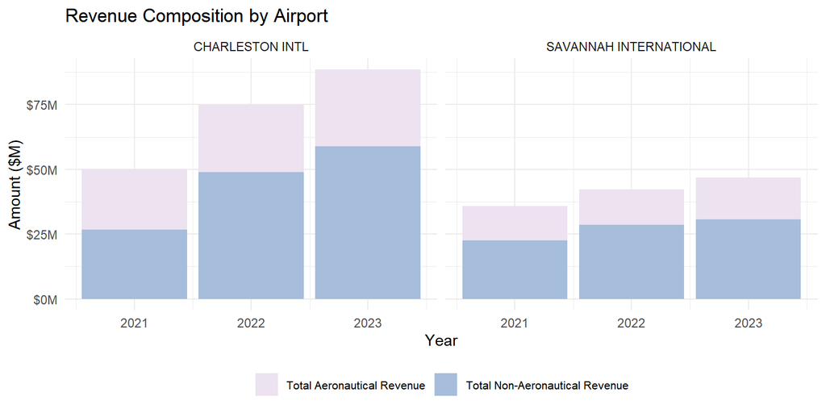

```r
# 2. revenue breakdown analysis
revenue_breakdown <- charleston_sav_analysis %>%
  select(`Airport Name`, Year,
         `Total Aeronautical Revenue`,
         `Total Non-Aeronautical Revenue`) %>%
  pivot_longer(cols = c(`Total Aeronautical Revenue`, `Total Non-Aeronautical Revenue`),
               names_to = "Revenue_Type",
               values_to = "Amount")

ggplot(revenue_breakdown,
       aes(x = Year, y = Amount, fill = Revenue_Type)) +
  geom_bar(stat = "identity", position = "stack") +
  facet_wrap(~`Airport Name`) +
    scale_fill_brewer(palette = "PuBuGn") +
  theme_minimal() +
  scale_y_continuous(labels = scales::label_number(prefix = "$", suffix = "M", scale = 1e-6)) +
  labs(title = "Revenue Composition by Airport",
       y = "Amount ($M)",
       fill = "Revenue Type") +
  theme(legend.position = "bottom",
        legend.text = element_text(size = 8),  # Smaller text
    legend.title = element_blank() )
```

Both Charleston and Savannah International airports consistently generate more revenue from non-aeronautical sources than aeronautical sources across 2021-2023, with Charleston showing a particularly dramatic increase. Charleston’s non-aeronautical revenue nearly doubled during this period, growing to represent over 60% of total revenue by 2023, while Savannah maintained a similar proportion but with more modest overall growth.

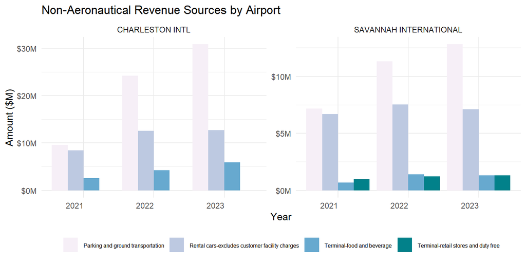

```r
# 3. Detailed non-aeronautical revenue analysis
non_aero_breakdown <- charleston_sav_analysis %>%
  select(`Airport Name`, Year,
         `Parking and ground transportation`,
         `Terminal-food and beverage`,
         `Terminal-retail stores and duty free`,
         `Rental cars-excludes customer facility charges`) %>%
  pivot_longer(cols = -c(`Airport Name`, Year),
               names_to = "Revenue_Source",
               values_to = "Amount")

# Visualize non-aeronautical revenue breakdown
ggplot(non_aero_breakdown, aes(x = factor(Year), y = Amount, fill = Revenue_Source)) +
  geom_col(position = "dodge") +
  facet_wrap(~`Airport Name`, scales = "free_y") +
  scale_y_continuous(labels = scales::label_number(prefix = "$", suffix = "M", scale = 1e-6)) +
  scale_fill_brewer(palette = "PuBuGn") +
  theme_minimal() +
  theme(
    axis.text.x = element_text(angle = 0, hjust = 1),
    legend.position = "bottom",
    legend.text = element_text(size = 6),  # Smaller text
    legend.title = element_blank()
  ) +
  labs(x = "Year",
       y = "Amount ($M)",
       title = "Non-Aeronautical Revenue Sources by Airport",
       fill = "Revenue Source")
```

```r
# 4. Calculate revenue per enplanement
revenue_metrics <- charleston_sav_analysis %>%
  group_by(`Airport Name`, Year) %>%
  summarize(
    Revenue_Per_Enplanement = `Total Operating Revenue` / Enplanements,
    Aero_Revenue_Per_Enplanement = `Total Aeronautical Revenue` / Enplanements,
    Non_Aero_Revenue_Per_Enplanement = `Total Non-Aeronautical Revenue` / Enplanements
  )

#print(revenue_metrics)
```

Parking and ground transportation represents the largest non-aeronautical revenue source at both airports, with Charleston experiencing remarkable growth in this category, tripling from $10M in 2021 to over $30M by 2023. Rental car revenue remains the second largest revenue source at both airports, while Savannah International shows more diversity in its terminal revenue with a more significant contribution from retail stores and duty-free compared to Charleston’s greater emphasis on food and beverage.

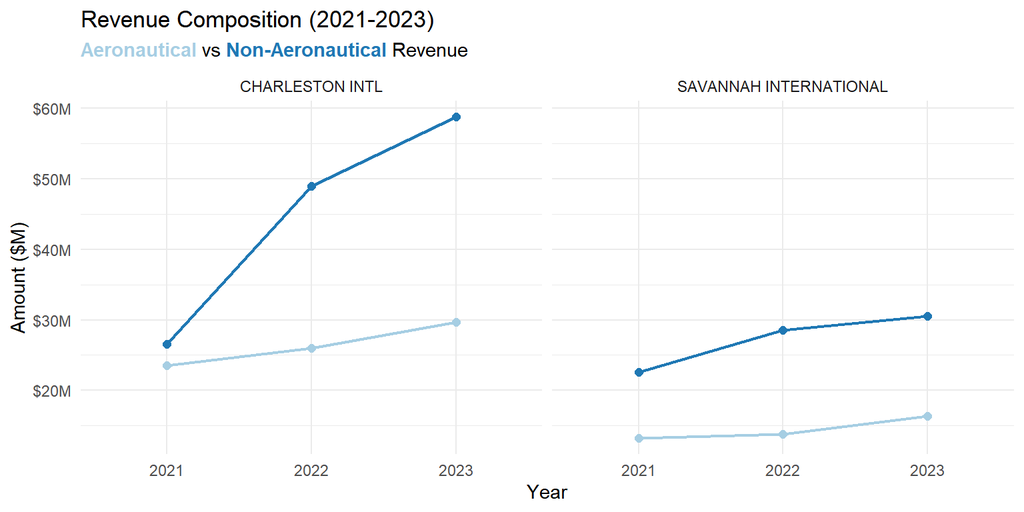

```r
ggplot(charleston_sav_analysis,
      aes(x = as.factor(Year))) +
 geom_line(aes(y = `Total Aeronautical Revenue`, color = "Aeronautical", group = 1), size = 0.8) +
 geom_line(aes(y = `Total Non-Aeronautical Revenue`, color = "Non-Aeronautical", group = 1), size = 0.8) +
 geom_point(aes(y = `Total Aeronautical Revenue`, color = "Aeronautical"), size = 2) +
 geom_point(aes(y = `Total Non-Aeronautical Revenue`, color = "Non-Aeronautical"), size = 2) +
 facet_wrap(~`Airport Name`) +
 theme_minimal() +
  theme(plot.subtitle = element_markdown()) +
 scale_y_continuous(labels = scales::label_number(prefix="$", suffix="M", scale=1e-6)) +
 scale_color_brewer(palette="Paired") +
 #scale_color_manual(values = c("#FF7F7F", "#7FB3D5")) +
 labs(title = "Revenue Composition (2021-2023)",
      subtitle = " **<span style='color:#a6cee3;'>Aeronautical</span>** vs **<span style='color:#1f78b4;'>Non-Aeronautical</span>** Revenue",
      y = "Amount ($M)",
      x = "Year",
      color = "Revenue Type")+
  theme(
  legend.position = "none",
  plot.subtitle = element_markdown()
)#+
```

```r
# theme(
#   legend.position = "bottom",
#   plot.title = element_text(hjust = 0.5),
#   plot.subtitle = element_text(hjust = 0.5)
# )
```

The chart shows Charleston’s remarkable non-aeronautical revenue growth, more than doubling from approximately $27M in 2021 to nearly $60M by 2023, significantly outpacing its aeronautical revenue growth. In contrast, Savannah shows more modest and balanced growth across both revenue streams, with non-aeronautical revenue increasing from about $22M to $30M.

```r
# year-over-year changes for each category
revenue_changes <- charleston_sav_analysis %>%
  arrange(`Airport Name`, Year) %>%
  group_by(`Airport Name`) %>%
  mutate(
    # Calculate YoY changes for each category
    Total_Revenue_YoY = (`Total Operating Revenue` - lag(`Total Operating Revenue`)) / lag(`Total Operating Revenue`) * 100,
    Passenger_Fees_YoY = (`Passenger airline landing fees` - lag(`Passenger airline landing fees`)) / lag(`Passenger airline landing fees`) * 100,
    Parking_Revenue_YoY = (`Parking and ground transportation` - lag(`Parking and ground transportation`)) / lag(`Parking and ground transportation`) * 100,
    Terminal_F_B_YoY = (`Terminal-food and beverage` - lag(`Terminal-food and beverage`)) / lag(`Terminal-food and beverage`) * 100,
    Rental_Cars_YoY = (`Rental cars-excludes customer facility charges` - lag(`Rental cars-excludes customer facility charges`)) / lag(`Rental cars-excludes customer facility charges`) * 100
  ) %>%
  ungroup()

# Now create the comparison visualization
revenue_comparison <- revenue_changes %>%
  select(`Airport Name`, Year,
         Total_Revenue_YoY,
         Passenger_Fees_YoY,
         Parking_Revenue_YoY,
         Terminal_F_B_YoY,
         Rental_Cars_YoY) %>%
  pivot_longer(cols = ends_with("YoY"),
               names_to = "Category",
               values_to = "Percent_Change") %>%
  # Clean up category names for display
  mutate(Category = gsub("_YoY", "", Category),
         Category = gsub("_", " ", Category))
```

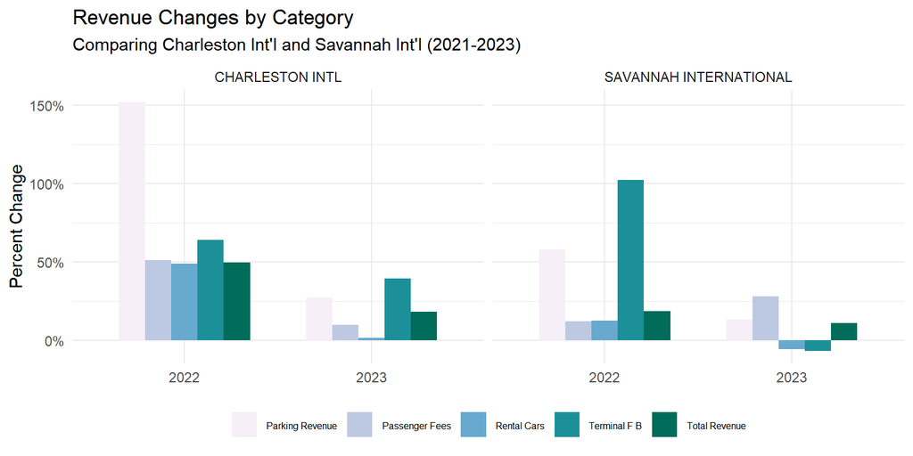

```r
# Creating the year-over-year comparison with Year as the x-axis
revenue_comparison <- revenue_changes %>%
  select(`Airport Name`, Year,
         Total_Revenue_YoY,
         Passenger_Fees_YoY,
         Parking_Revenue_YoY,
         Terminal_F_B_YoY,
         Rental_Cars_YoY) %>%
  pivot_longer(cols = ends_with("YoY"),
               names_to = "Category",
               values_to = "Percent_Change") %>%
  # Clean up category names for display
  mutate(Category = gsub("_YoY", "", Category),
         Category = gsub("_", " ", Category))

# Create bar chart with Year on x-axis
ggplot(revenue_comparison %>% filter(!is.na(Percent_Change)),
       aes(x = factor(Year), y = Percent_Change,
           fill = Category)) +
  geom_bar(stat = "identity",
           position = "dodge",
           width = 0.7) +
  facet_wrap(~`Airport Name`, scales = "fixed") +  # Changed to fixed scales
  theme_minimal() +
  theme(axis.text.x = element_text(angle = 0, hjust = 0.5),
        legend.position = "bottom",
        legend.text = element_text(size = 6),  # Smaller text
    legend.title = element_blank() ) +
  scale_y_continuous(labels = scales::percent_format(scale = 1)) +
  labs(title = "Revenue Changes by Category",
       subtitle = "Comparing Charleston Int'l and Savannah Int'l (2021-2023)",
       y = "Percent Change",
       x = NULL,
       fill = "Revenue Category") +
  scale_fill_brewer(palette = "PuBuGn")
```

```r
# Print summary statistics with kable
summary_stats <- revenue_comparison %>%
  group_by(Category, `Airport Name`) %>%
  summarize(
    Mean_Change = mean(Percent_Change, na.rm = TRUE),
    Max_Change = max(Percent_Change, na.rm = TRUE),
    Min_Change = min(Percent_Change, na.rm = TRUE),
    .groups = "drop"
  ) %>%
  arrange(Category, `Airport Name`) %>%
  mutate(
    Mean_Change = round(Mean_Change, 2),
   Max_Change = round(Max_Change, 2),
   Min_Change = round(Min_Change, 2)
  )

# Create a nicely formatted table with kable
summary_stats %>%
  kable(
    format = "markdown",
    col.names = c("Revenue Category", "Airport", "Mean Change (%)", "Max Change (%)", "Min Change (%)"),
    caption = "Percentage Changes in Revenue Categories (2021-2023)",
    digits = 2,
    align = c('l', 'l', 'r', 'r', 'r')
  ) %>%
  kable_styling(
    bootstrap_options = c("striped", "hover", "condensed"),
    full_width = FALSE
  ) %>%
  add_header_above(c(" " = 2, "Year-over-Year Changes (%)" = 3))
```

Percentage Changes in Revenue Categories (2021-2023)

| Revenue Category | Airport | Year-over-Year Changes (%) Mean Change (%) | Year-over-Year Changes (%) Max Change (%) | Year-over-Year Changes (%) Min Change (%) |
| --- | --- | --- | --- | --- |
| Parking Revenue | CHARLESTON INTL | 89.63 | 151.99 | 27.27 |
| Parking Revenue | SAVANNAH INTERNATIONAL | 35.56 | 58.05 | 13.07 |
| Passenger Fees | CHARLESTON INTL | 30.59 | 51.20 | 9.97 |
| Passenger Fees | SAVANNAH INTERNATIONAL | 20.09 | 27.99 | 12.19 |
| Rental Cars | CHARLESTON INTL | 25.18 | 49.00 | 1.36 |
| Rental Cars | SAVANNAH INTERNATIONAL | 3.51 | 12.57 | -5.55 |
| Terminal F B | CHARLESTON INTL | 51.62 | 63.82 | 39.42 |
| Terminal F B | SAVANNAH INTERNATIONAL | 47.71 | 102.35 | -6.92 |
| Total Revenue | CHARLESTON INTL | 33.79 | 49.56 | 18.03 |
| Total Revenue | SAVANNAH INTERNATIONAL | 14.57 | 18.36 | 10.79 |

The Revenue Changes by Category chart highlights dramatic percentage increases across revenue categories, with Charleston’s parking revenue rising an extraordinary 152% in 2022. Terminal food and beverage showed remarkable growth at both airports, with Savannah experiencing a 102.4% increase in 2022 compared to Charleston’s 63.8%. Passenger fees grew substantially at both locations, while rental cars showed divergent patterns with Charleston maintaining positive growth and Savannah experiencing negative growth by 2023. These percentage changes indicate significant post-pandemic recovery with notably different trajectories at the two airports.

The detailed percentage table from 2021 to 2023 demonstrates post-pandemic recovery with diverging fortunes. Charleston’s impressive mean change of 89.6% in parking revenue vastly outperforms Savannah’s 35.6%, suggesting highly successful parking management strategies or increased visitor volume. Savannah shows concerning negative minimum values in both rental cars (-5.6%) and terminal food and beverage (-6.9%), indicating volatility in these revenue streams. Charleston maintained positive growth across all categories, with terminal food and beverage delivering the most consistent performance (minimum change of 39.4%). Particularly noteworthy is the difference in total revenue growth, where Charleston’s mean change of 33.8% more than doubles Savannah’s 14.6%, revealing fundamentally different revenue recovery patterns despite the airports’ regional proximity. These trends suggest Charleston has implemented more effective commercial strategies or benefits from stronger local economic factors driving airport usage.

## Exploring Cost Breakdown Over Time

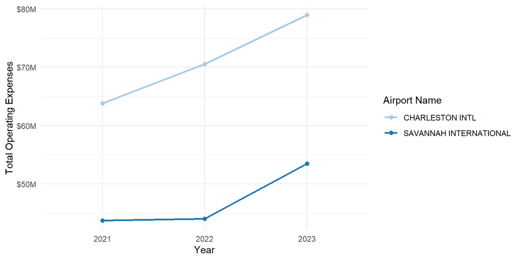

```r
# Key Cost Metrics
#`Personnel compensation and benefits`,
#`Communications and utilities`,
#`Supplies and materials`,
#`Contractual services`,
#`Total Operating Expenses`,
#`Operating Income`,

ggplot(charleston_sav_analysis, aes(x=factor(Year), y=`Total Operating Expenses`, group=`Airport Name`)) +
  geom_line(aes(color=`Airport Name`), size = 1) +
  geom_point(aes(color=`Airport Name`), size = 2) +
  scale_color_brewer(palette="Paired") +
  scale_x_discrete(breaks=c("2021", "2022", "2023")) +
  scale_y_continuous(labels = scales::label_number(prefix="$", suffix="M", scale=1e-6)) +
  theme_minimal() +
  labs(x="Year",
       y="Total Operating Expenses",
       color="Airport Name")
```

Both Charleston and Savannah airports show consistent upward trends in operating expenses from 2021 to 2023. Charleston’s expenses grew more significantly in absolute terms, rising from approximately $64M to $78M, while Savannah’s increased from about $44M to $54M. The steepest increase for both airports occurred between 2022 and 2023, indicating accelerating operational costs in the most recent period, likely due to inflation and post-pandemic service expansion.

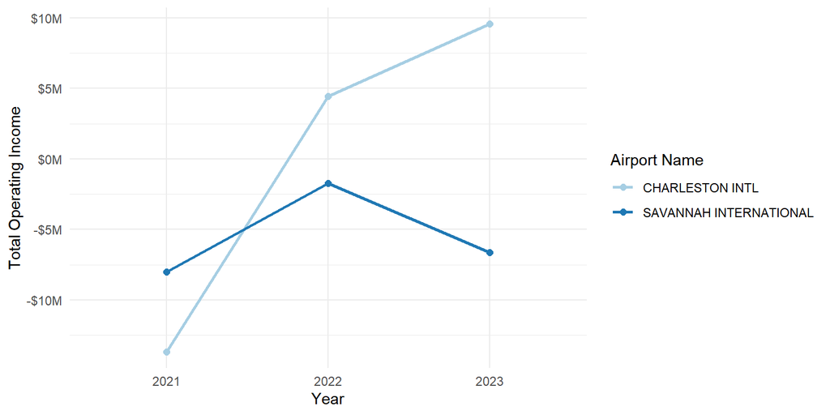

```r
# Visualizing expenses vs. income
ggplot(charleston_sav_analysis, aes(x=factor(Year), y=`Operating Income`, group=`Airport Name`)) +
  geom_line(aes(color=`Airport Name`), size = 1) +
  geom_point(aes(color=`Airport Name`), size = 2) +
  scale_color_brewer(palette="Paired") +
  scale_x_discrete(breaks=c("2021", "2022", "2023")) +
  scale_y_continuous(labels = scales::label_number(prefix="$", suffix="M", scale=1e-6)) +
  theme_minimal() +
  labs(x="Year",
       y="Total Operating Income",
       color="Airport Name")
```

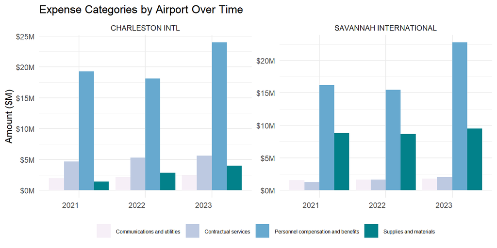

```r
expenses_long <- charleston_sav_analysis %>%
  pivot_longer(
    cols = c(`Personnel compensation and benefits`,
             `Communications and utilities`,
             `Supplies and materials`,
             `Contractual services`),
    names_to = "Category",
    values_to = "Amount"
  )

ggplot(expenses_long, aes(x=factor(Year), y=Amount, fill=Category)) +
  geom_col(position="dodge") +
  facet_wrap(~`Airport Name`, scales="free_y") +
  scale_y_continuous(labels = scales::label_number(prefix="$", suffix="M", scale=1e-6)) +
  scale_fill_brewer(palette="PuBuGn") +
  theme_minimal() +
  theme(
    axis.text.x = element_text(angle = 0, hjust = 1),
    legend.position = "bottom",
    legend.text = element_text(size = 6),  # Smaller text
    legend.title = element_blank()
  ) +
  labs(x=NULL,
       y="Amount ($M)",
       title="Expense Categories by Airport Over Time",
       fill="Expense Category")
```

```r
# Calculate specific cost changes over time to see which areas of expense experienced higher investment or cuts
changes_table <- charleston_sav_analysis %>%
  select(`Airport Name`, Year,
         `Personnel compensation and benefits`,
         `Communications and utilities`,
         `Supplies and materials`,
         `Contractual services`) %>%
  group_by(`Airport Name`) %>%
  summarize(
    # Personnel
    `Personnel % Change 2021-2022` = ((`Personnel compensation and benefits`[Year == 2022] -
                                      `Personnel compensation and benefits`[Year == 2021]) /
                                      `Personnel compensation and benefits`[Year == 2021] * 100),
    `Personnel % Change 2022-2023` = ((`Personnel compensation and benefits`[Year == 2023] -
                                      `Personnel compensation and benefits`[Year == 2022]) /
                                      `Personnel compensation and benefits`[Year == 2022] * 100),
    `Personnel Total % Change` = ((`Personnel compensation and benefits`[Year == 2023] -
                                  `Personnel compensation and benefits`[Year == 2021]) /
                                  `Personnel compensation and benefits`[Year == 2021] * 100),

    # Communications
    `Communications % Change 2021-2022` = ((`Communications and utilities`[Year == 2022] -
                                          `Communications and utilities`[Year == 2021]) /
                                          `Communications and utilities`[Year == 2021] * 100),
    `Communications % Change 2022-2023` = ((`Communications and utilities`[Year == 2023] -
                                          `Communications and utilities`[Year == 2022]) /
                                          `Communications and utilities`[Year == 2022] * 100),
    `Communications Total % Change` = ((`Communications and utilities`[Year == 2023] -
                                      `Communications and utilities`[Year == 2021]) /
                                      `Communications and utilities`[Year == 2021] * 100),

    # Supplies
    `Supplies % Change 2021-2022` = ((`Supplies and materials`[Year == 2022] -
                                     `Supplies and materials`[Year == 2021]) /
                                     `Supplies and materials`[Year == 2021] * 100),
    `Supplies % Change 2022-2023` = ((`Supplies and materials`[Year == 2023] -
                                     `Supplies and materials`[Year == 2022]) /
                                     `Supplies and materials`[Year == 2022] * 100),
    `Supplies Total % Change` = ((`Supplies and materials`[Year == 2023] -
                                 `Supplies and materials`[Year == 2021]) /
                                 `Supplies and materials`[Year == 2021] * 100),

    # Contractual
    `Contractual % Change 2021-2022` = ((`Contractual services`[Year == 2022] -
                                        `Contractual services`[Year == 2021]) /
                                        `Contractual services`[Year == 2021] * 100),
    `Contractual % Change 2022-2023` = ((`Contractual services`[Year == 2023] -
                                        `Contractual services`[Year == 2022]) /
                                        `Contractual services`[Year == 2022] * 100),
    `Contractual Total % Change` = ((`Contractual services`[Year == 2023] -
                                    `Contractual services`[Year == 2021]) /
                                    `Contractual services`[Year == 2021] * 100)
  ) %>%
  # Round all numeric columns to 1 decimal place
  mutate(across(where(is.numeric), ~round(., 1)))


#changes_table %>%
  #kable(format = "markdown",
        #caption = "Percentage Changes in Expense Categories (2021-2023)")


changes_table %>%
  kable(
    format = "markdown",
    col.names = c("Airport",
                 "Personnel 2021-2022", "Personnel 2022-2023", "Personnel Total",
                 "Communications 2021-2022", "Communications 2022-2023", "Communications Total",
                 "Supplies 2021-2022", "Supplies 2022-2023", "Supplies Total",
                 "Contractual 2021-2022", "Contractual 2022-2023", "Contractual Total"),
    caption = "Percentage Changes in Expense Categories (2021-2023)",
    digits = 1,
    align = c('l', rep('r', 12))
  ) %>%
  kable_styling(
    bootstrap_options = c("striped", "hover", "condensed"),
    full_width = FALSE
  ) %>%
  add_header_above(c(" " = 1,
                    "Personnel (%)" = 3,
                    "Communications (%)" = 3,
                    "Supplies (%)" = 3,
                    "Contractual Services (%)" = 3))
```

Percentage Changes in Expense Categories (2021-2023)

| Airport | Personnel (%) Personnel 2021-2022 | Personnel (%) Personnel 2022-2023 | Personnel (%) Personnel Total | Communications (%) Communications 2021-2022 | Communications (%) Communications 2022-2023 | Communications (%) Communications Total | Supplies (%) Supplies 2021-2022 | Supplies (%) Supplies 2022-2023 | Supplies (%) Supplies Total | Contractual Services (%) Contractual 2021-2022 | Contractual Services (%) Contractual 2022-2023 | Contractual Services (%) Contractual Total |
| --- | --- | --- | --- | --- | --- | --- | --- | --- | --- | --- | --- | --- |
| CHARLESTON INTL | -5.9 | 32.3 | 24.6 | 10.8 | 10.8 | 22.9 | 97.9 | 42.4 | 181.7 | 13.3 | 6.3 | 20.5 |
| SAVANNAH INTERNATIONAL | -4.6 | 47.1 | 40.4 | 6.0 | 8.6 | 15.1 | -1.7 | 9.3 | 7.5 | 31.7 | 25.2 | 64.9 |